# Hack(her)413

**STRAY DETECT SYSTEM**

1. This system will allow visually impaired or challenged people to detect any stray animals while walking on the walking tracks of the road.
2. This will also help self driving cars to detect any stray animals and thus save their lives

```python
%tensorflow_version 2.x
import tensorflow
tensorflow.__version__
```

```
TensorFlow 2.x selected.
```

```
'2.1.0'
```

```python
# Initialize the random number generator
import random
random.seed(0)

# Ignore the warnings
import warnings
warnings.filterwarnings("ignore")
```

### Load the dataset

As we are using google colab, we need to mount the google drive to load the data file

```python
from google.colab import drive
drive.mount('/content/drive/')
```

Add path to the folder where your dataset files are

```python
project_path = '/content/drive/My Drive/HACK143/'
```

All our images are in the zip file so we need to extract the contents of this file

```python
images_zip_path = project_path + "images.zip"

from zipfile import ZipFile

with ZipFile(images_zip_path, 'r') as z:
  z.extractall()
```

### Define the neccessary parameters

```python
ALPHA = 1 # Width hyper parameter for MobileNet (0.25, 0.5, 0.75, 1.0). Higher width means more accurate but slower

IMAGE_HEIGHT = 224
IMAGE_WIDTH = 224

HEIGHT_CELLS = 28
WIDTH_CELLS = 28

IMAGE_SIZE = 224

TRAIN_CSV = project_path + "train.csv"
VALIDATION_CSV = project_path + "validation.csv"
```

### Creating training data

```python
import numpy as np
import csv
import cv2

with open(TRAIN_CSV, "r") as file:

  # Create an empty array for storing mask details.
  y_train = np.zeros((sum(1 for line in file), HEIGHT_CELLS, WIDTH_CELLS))
  print("y_train_shape:", y_train.shape)
  X_train_path = []
  file.seek(0)

  data = csv.reader(file, delimiter=',')

  for index, row in enumerate(data):
    for i, r in enumerate(row[1:7]):
        row[i+1] = int(r)

    path, image_height, image_width, x0, y0, x1, y1, _, _ = row

    path = "./" + path.split('/')[-2] + "/" + path.split('/')[-1]
    path_mask = path.replace('.jpg','.png')

    mask_img = cv2.imread(path_mask)
    mask_img = (mask_img!=2)*1.0
    mask_img = cv2.resize(mask_img, (28, 28))
    mask_img = 1.0*(mask_img[:,:,0]>0.2)

    y_train[index,:,:] = np.squeeze(mask_img)

    X_train_path.append(path)
```

```
y_train_shape: (3006, 28, 28)
```

```python
X_train_path[:5]
```

```
['./images/Abyssinian_1.jpg',
 './images/Abyssinian_10.jpg',
 './images/Abyssinian_100.jpg',
 './images/Abyssinian_101.jpg',
 './images/Abyssinian_102.jpg']
```

Plotting some of the training samples:

What is semantic segmentation:

- We put a label on each pixel of the image
- We desgin a fully convolutional neural network and then we pass the image through it so that it can predict for all pixels of the image at once.
- There wont be any restriction on the image size.
- It uses upsampling and downsampling inside the convolutional NN.

First example

[figure not shown]

```python
import matplotlib.pyplot as plt
plt.imshow(cv2.imread(X_train_path[6]))
```

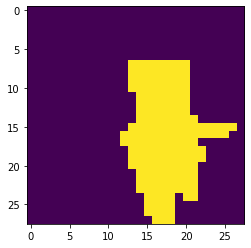

```python
plt.imshow(y_train[6])
```

Second example

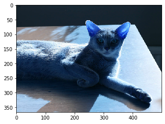

```python
plt.imshow(cv2.imread(X_train_path[17]))
```

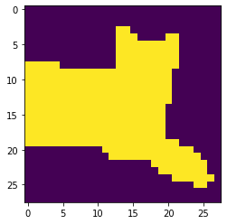

```python
plt.imshow(y_train[17])
```

Preprocessing of the images to convert them into an array

```python
X_train = X_train_path
```

```python
from PIL import Image
from tensorflow.keras.applications.mobilenet import preprocess_input

for i, f in enumerate(X_train_path):
  img = Image.open(f) # Read image
  img = img.resize((IMAGE_SIZE, IMAGE_SIZE)) # Resize image
  img = img.convert('RGB')

  X_train[i] = preprocess_input(np.array(img, dtype=np.float32)) # Convert to float32 array
  img.close()
```

```python
X_train = np.array(X_train)
X_train.shape
```

```
(3006, 224, 224, 3)
```

### Creating validation data

```python
with open(VALIDATION_CSV, "r") as file:
  y_val = np.zeros((sum(1 for line in file), HEIGHT_CELLS, WIDTH_CELLS))
  print(y_val.shape)
  X_val_path = []
  file.seek(0)

  data = csv.reader(file, delimiter=',')

  for index, row in enumerate(data):
    for i, r in enumerate(row[1:7]):
        row[i+1] = int(r)

    path, image_height, image_width, x0, y0, x1, y1, _, _ = row

    path = "./" + path.split('/')[-2] + "/" + path.split('/')[-1]
    path_mask = path.replace('.jpg','.png')

    mask_img = cv2.imread(path_mask)
    mask_img = (mask_img!=2)*1.0
    mask_img = cv2.resize(mask_img, (28, 28))
    mask_img = 1.0*(mask_img[:,:,0]>0.2)
    y_val[index,:,:] = np.squeeze(mask_img)

    X_val_path.append(path)
```

```
(680, 28, 28)
```

#### Let's visualize some validation examples

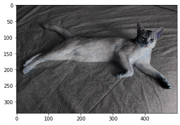

```python
plt.imshow(cv2.imread(X_val_path[6]))
```

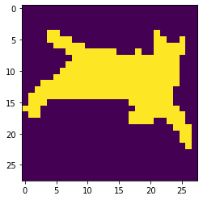

```python
import matplotlib.pyplot as plt
plt.imshow(y_val[6])
```

#### Preprocess the validation feature images and convert them into an array which is compatable with Mobilenet

```python
X_val = X_val_path
```

```python
from PIL import Image
from tensorflow.keras.applications.mobilenet import preprocess_input

for i, f in enumerate(X_val_path):
  img = Image.open(f) # Read image
  img = img.resize((IMAGE_SIZE, IMAGE_SIZE)) # Resize image
  img = img.convert('RGB')

  X_val[i] = preprocess_input(np.array(img, dtype=np.float32)) # Convert to float32 array
  img.close()
```

```python
X_val = np.array(X_val)
X_val.shape
```

```
(680, 224, 224, 3)
```

### Let's create our model now

```python
from tensorflow.keras.applications.mobilenet import MobileNet
from tensorflow.keras.layers import Concatenate, Conv2D, Reshape, UpSampling2D
from tensorflow.keras.models import Model

def create_model(trainable=True):
    model = MobileNet(input_shape=(IMAGE_HEIGHT, IMAGE_WIDTH, 3), include_top=False, alpha=ALPHA, weights="imagenet")

    for layer in model.layers:
        layer.trainable = trainable

    block1 = model.get_layer("conv_pw_5_relu").output
    block2 = model.get_layer("conv_pw_11_relu").output
    block3 = model.get_layer("conv_pw_13_relu").output

    x = Concatenate()([UpSampling2D()(block3), block2])
    x = Concatenate()([UpSampling2D()(x), block1])

    x = Conv2D(1, kernel_size=1, activation="sigmoid")(x)
    x = Reshape((HEIGHT_CELLS, WIDTH_CELLS))(x)

    return Model(inputs=model.input, outputs=x)
```

#### Define dice coefficient

" Dice Coefficient is 2 * the Area of Overlap divided by the total number of pixels in both images. "

(Taken from https://towardsdatascience.com/metrics-to-evaluate-your-semantic-segmentation-model-6bcb99639aa2 )

```python
def dice_coefficient(y_true, y_pred):
    numerator = 2 * tensorflow.reduce_sum(y_true * y_pred)
    denominator = tensorflow.reduce_sum(y_true + y_pred)

    return numerator / (denominator + tensorflow.keras.backend.epsilon())
```

#### Define loss function

```python
def loss(y_true, y_pred):
    return binary_crossentropy(y_true, y_pred) - tensorflow.keras.backend.log(dice_coefficient(y_true, y_pred) + tensorflow.keras.backend.epsilon())
```

### Create the model and print summary

```python
model = create_model(False)
model.summary()
```

```
Downloading data from https://github.com/fchollet/deep-learning-models/releases/download/v0.6/mobilenet_1_0_224_tf_no_top.h5
Model: "model"
__________________________________________________________________________________________________
Layer (type)                    Output Shape         Param #     Connected to
==================================================================================================
input_1 (InputLayer)            [(None, 224, 224, 3) 0
__________________________________________________________________________________________________
conv1_pad (ZeroPadding2D)       (None, 225, 225, 3)  0           input_1[0][0]
__________________________________________________________________________________________________
conv1 (Conv2D)                  (None, 112, 112, 32) 864         conv1_pad[0][0]
__________________________________________________________________________________________________
conv1_bn (BatchNormalization)   (None, 112, 112, 32) 128         conv1[0][0]
__________________________________________________________________________________________________
conv1_relu (ReLU)               (None, 112, 112, 32) 0           conv1_bn[0][0]
__________________________________________________________________________________________________
conv_dw_1 (DepthwiseConv2D)     (None, 112, 112, 32) 288         conv1_relu[0][0]
__________________________________________________________________________________________________
conv_dw_1_bn (BatchNormalizatio (None, 112, 112, 32) 128         conv_dw_1[0][0]
__________________________________________________________________________________________________
conv_dw_1_relu (ReLU)           (None, 112, 112, 32) 0           conv_dw_1_bn[0][0]
__________________________________________________________________________________________________
conv_pw_1 (Conv2D)              (None, 112, 112, 64) 2048        conv_dw_1_relu[0][0]
__________________________________________________________________________________________________
conv_pw_1_bn (BatchNormalizatio (None, 112, 112, 64) 256         conv_pw_1[0][0]
__________________________________________________________________________________________________
conv_pw_1_relu (ReLU)           (None, 112, 112, 64) 0           conv_pw_1_bn[0][0]
__________________________________________________________________________________________________
conv_pad_2 (ZeroPadding2D)      (None, 113, 113, 64) 0           conv_pw_1_relu[0][0]
__________________________________________________________________________________________________
conv_dw_2 (DepthwiseConv2D)     (None, 56, 56, 64)   576         conv_pad_2[0][0]
__________________________________________________________________________________________________
conv_dw_2_bn (BatchNormalizatio (None, 56, 56, 64)   256         conv_dw_2[0][0]
__________________________________________________________________________________________________
conv_dw_2_relu (ReLU)           (None, 56, 56, 64)   0           conv_dw_2_bn[0][0]
__________________________________________________________________________________________________
conv_pw_2 (Conv2D)              (None, 56, 56, 128)  8192        conv_dw_2_relu[0][0]
__________________________________________________________________________________________________
conv_pw_2_bn (BatchNormalizatio (None, 56, 56, 128)  512         conv_pw_2[0][0]
__________________________________________________________________________________________________
conv_pw_2_relu (ReLU)           (None, 56, 56, 128)  0           conv_pw_2_bn[0][0]
```

[output cut: 142 more lines]

```
                                                                 conv_pw_11_relu[0][0]
__________________________________________________________________________________________________
up_sampling2d_1 (UpSampling2D)  (None, 28, 28, 1536) 0           concatenate[0][0]
__________________________________________________________________________________________________
concatenate_1 (Concatenate)     (None, 28, 28, 1792) 0           up_sampling2d_1[0][0]
                                                                 conv_pw_5_relu[0][0]
__________________________________________________________________________________________________
conv2d (Conv2D)                 (None, 28, 28, 1)    1793        concatenate_1[0][0]
__________________________________________________________________________________________________
reshape (Reshape)               (None, 28, 28)       0           conv2d[0][0]
==================================================================================================
Total params: 3,230,657
Trainable params: 1,793
Non-trainable params: 3,228,864
__________________________________________________________________________________________________
```

Compiling the model

```python
from tensorflow.keras.optimizers import Adam
from tensorflow.keras.losses import binary_crossentropy

optimizer = Adam(lr=1e-4, beta_1=0.9, beta_2=0.999, epsilon=None, decay=0.0, amsgrad=False)
model.compile(loss=loss, optimizer=optimizer, metrics=[dice_coefficient])
```

### Define callbacks

```python
from tensorflow.keras.callbacks import ModelCheckpoint, EarlyStopping, ReduceLROnPlateau

checkpoint = ModelCheckpoint("model-{val_loss:.2f}.h5", monitor="val_loss", verbose=1, save_best_only=True, save_weights_only=True)

stop = EarlyStopping(monitor="val_loss", patience=5)

reduce_lr = ReduceLROnPlateau(monitor="val_loss", factor=0.2, patience=5, min_lr=1e-6, verbose=1)
```

### Fit the model

```python
model.fit(X_train, y_train, validation_data = (X_val, y_val), epochs=1, batch_size=32, verbose=1)
```

```
Train on 3006 samples, validate on 680 samples
```

[output not shown]

[output cut: 28 more lines]

[output not shown]

PREDICTION TIMEEE!!!

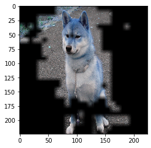

```python
import matplotlib.pyplot as plt
filename = './images/shiba_inu_163.jpg'

unscaled = cv2.imread(filename)
image = cv2.resize(unscaled, (IMAGE_WIDTH, IMAGE_HEIGHT))
feat_scaled = preprocess_input(np.array(image, dtype=np.float32))

pred_mask = cv2.resize(1.0*(model.predict(x=np.array([feat_scaled]))[0] > 0.5), (IMAGE_WIDTH,IMAGE_HEIGHT))

image2 = image
image2[:,:,0] = pred_mask*image[:,:,0]
image2[:,:,1] = pred_mask*image[:,:,1]
image2[:,:,2] = pred_mask*image[:,:,2]

out_image = image2

plt.imshow(out_image)
```

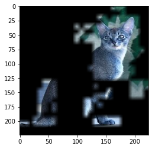

```python
import matplotlib.pyplot as plt
filename = './images/Abyssinian_13.jpg'

unscaled = cv2.imread(filename)
image = cv2.resize(unscaled, (IMAGE_WIDTH, IMAGE_HEIGHT))
feat_scaled = preprocess_input(np.array(image, dtype=np.float32))

pred_mask = cv2.resize(1.0*(model.predict(x=np.array([feat_scaled]))[0] > 0.5), (IMAGE_WIDTH,IMAGE_HEIGHT))

image2 = image
image2[:,:,0] = pred_mask*image[:,:,0]
image2[:,:,1] = pred_mask*image[:,:,1]
image2[:,:,2] = pred_mask*image[:,:,2]

out_image = image2

plt.imshow(out_image)
```

### Now, let's use pretrained weights

```python
WEIGHTS_FILE = project_path + "model-0.71.h5"
THRESHOLD = 0.8
EPSILON = 0.02

model = create_model()
model.load_weights(WEIGHTS_FILE)
```

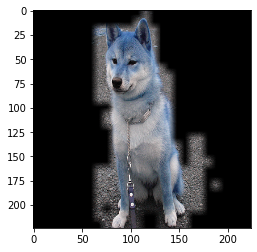

```python
filename = './images/shiba_inu_163.jpg'

unscaled = cv2.imread(filename)
image = cv2.resize(unscaled, (IMAGE_WIDTH, IMAGE_HEIGHT))
feat_scaled = preprocess_input(np.array(image, dtype=np.float32))

pred_mask = cv2.resize(1.0*(model.predict(x=np.array([feat_scaled]))[0] > 0.5), (IMAGE_WIDTH,IMAGE_HEIGHT))

image2 = image
image2[:,:,0] = pred_mask*image[:,:,0]
image2[:,:,1] = pred_mask*image[:,:,1]
image2[:,:,2] = pred_mask*image[:,:,2]

out_image = image2

plt.imshow(out_image)
```

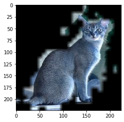

```python
import matplotlib.pyplot as plt
filename = './images/Abyssinian_13.jpg'

unscaled = cv2.imread(filename)
image = cv2.resize(unscaled, (IMAGE_WIDTH, IMAGE_HEIGHT))
feat_scaled = preprocess_input(np.array(image, dtype=np.float32))

pred_mask = cv2.resize(1.0*(model.predict(x=np.array([feat_scaled]))[0] > 0.5), (IMAGE_WIDTH,IMAGE_HEIGHT))

image2 = image
image2[:,:,0] = pred_mask*image[:,:,0]
image2[:,:,1] = pred_mask*image[:,:,1]
image2[:,:,2] = pred_mask*image[:,:,2]

out_image = image2

plt.imshow(out_image)
```